# Introducción a la programación y análisis de datos en R

Día 3 · Bloque 2 — La fórmula en R, cor.test(), t.test()

Filip Andras

CIMCYC — Universidad de Granada

23 octubre 2026

## Mapa del día 3

Bloque 1  
9:00 – 10:30

Datos anchos y largos

De ancho a largo: `pivot_longer()`

Ej. 1

De largo a ancho: `pivot_wider()`

Ej. 2

Tip: descriptivos de golpe

Bloque 2  
11:00 – 12:30

La fórmula en R: `VD ~ VI`

Correlación: `cor.test()`

Ej. 3

Comparar dos grupos: `t.test()`

Ej. 4

Bloque 3  
13:00 – 14:00 · 60’

ANOVA: Fisher y la *F*

ANOVA de una vía: `aov_car()`

Ej. 5

ANOVA mixto: interacción

# La fórmula en R: `VD ~ VI`

## Recordatorio: nuestro ensayo clínico (RCT)

- **300 pacientes** asignados aleatoriamente a 3 grupos
- **CBT** (terapia cognitivo-conductual), **farmacológico**, **control**
- Variables: ansiedad (GAD-7), depresión (PHQ-9), bienestar, soledad (UCLA), autoestima (Rosenberg)
- Medidas **pre** y **post** tratamiento

**Preguntas que vamos a responder:**

1. ¿Hay relación entre la ansiedad y el bienestar?

→

Correlación

2. ¿Difiere la ansiedad basal (pre) del grupo farmacológico de la del grupo control?

→

*t*-test independiente

3. ¿Cambia la ansiedad del grupo CBT entre el pre y el post?

→

*t*-test pareado

4. ¿Cambia la ansiedad de forma distinta en cada grupo a lo largo del tiempo?

→

ANOVA mixto

bloque 2 bloque 3 solo se presenta

## La fórmula en R: `VD ~ VI`

En R, casi todos los análisis estadísticos se escriben con la misma estructura: una **fórmula**.

`~` se lee **“en función de”**: a la izquierda lo que **medimos** (VD), a la derecha lo que lo **explica** (VI).

VD ~ VI

→ la VD en función de la VI

anxiety_post ~ group

→ la ansiedad post en función del grupo

VD ~ VI1 + VI2

→ efectos principales de las dos VI

VD ~ VI1 * VI2

→ efectos principales + interacción

VD ~ 1

→ sin VI: solo la media

Hoy la vamos a escribir en `plot()`, `boxplot()`, `cor.test()`, `leveneTest()`, `t.test()`, `cohens_d()` y, en el bloque 3, `aov_car()`.

# Relación entre dos variables: `cor.test()`

## Un poco de historia: de Galton a Spearman

- **Francis Galton** (1888) estudia la estatura de padres e hijos y la longitud del antebrazo, y habla por primera vez de *co-relation*
- **Karl Pearson** (1896) da la fórmula del coeficiente que usamos hoy: la correlación **de Pearson**
- **Charles Spearman** (1904), **psicólogo**, propone la correlación por rangos para medir la asociación entre capacidades mentales: la correlación **de Spearman**

## ¿Qué es una correlación?

- Mide la **relación lineal** entre dos variables numéricas
- Rango: de **-1** (negativa perfecta) a **+1** (positiva perfecta); **0** = sin relación
- **Pearson**: asume normalidad en ambas variables
- **Spearman**: basada en rangos, no asume normalidad, mide relación **monótonas** (no necesariamente lineales)
- **¡Correlación != causalidad!**

## ¿Cómo se ve cada valor de r?

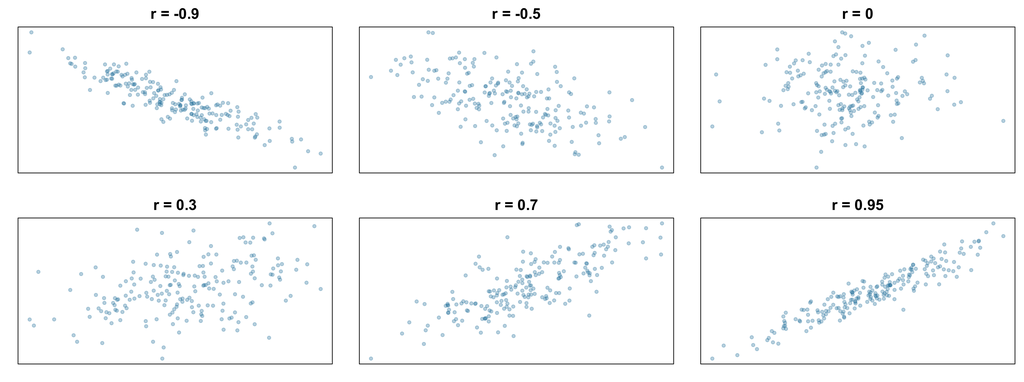

## Mismo r, datos muy distintos: el cuarteto de Anscombe

El estadístico Francis Anscombe (1973) construyó **cuatro conjuntos de datos** con la misma media (x = 9, y = 7.5), la misma desviación típica, la misma recta y **la misma correlación, r = 0.82**. ¿Describe r = 0.82 igual de bien los cuatro?

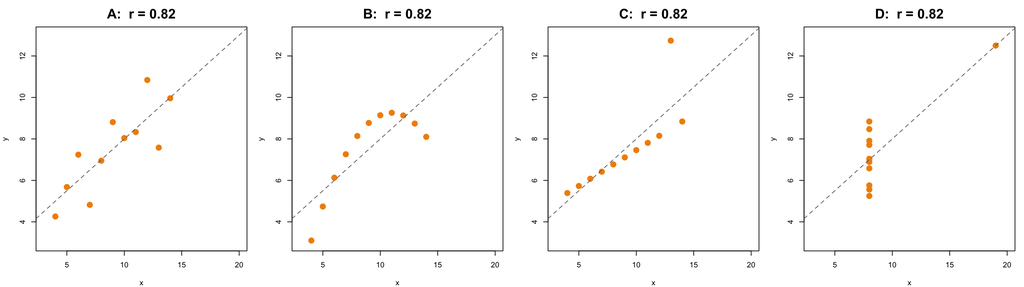

- **A**: una nube alargada alrededor de la recta: es lo que imaginamos al leer r = 0.82
- **B**: los puntos forman una **curva** perfecta; Pearson solo mide relaciones lineales y no la ve
- **C**: todos los puntos están en una recta perfecta (r = 1) **salvo uno**; ese valor atípico baja r a 0.82
- **D**: x vale 8 en todos los puntos **salvo uno**; sin ese punto no habría ninguna relación
- Conclusión: el mismo r puede esconder datos muy distintos: **mira siempre el gráfico**

## Pregunta: ¿se relacionan ansiedad y bienestar?

```r
# eje y en funcion del eje x
plot(formula = anxiety_post ~ wellbeing_post,
     data = data_trial)
```

Parece haber una **relación negativa y lineal**: más bienestar, menos ansiedad.

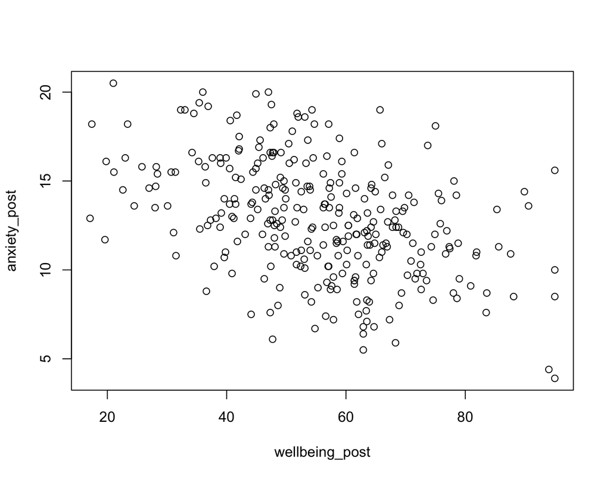

## Supuestos: normalidad con gráficos

```r
# histograma: forma de campana?
hist(x = data_trial$anxiety_post)

# QQ plot: puntos sobre la linea?
qqnorm(y = data_trial$anxiety_post)
qqline(y = data_trial$anxiety_post)
```

- **Histograma**: forma de campana, simétrica
- **QQ plot** (gráfico cuantil-cuantil): compara cada valor ordenado de nuestros datos con el que le correspondería si los datos fueran **exactamente normales**; si los puntos siguen la línea, los datos son compatibles con la normal

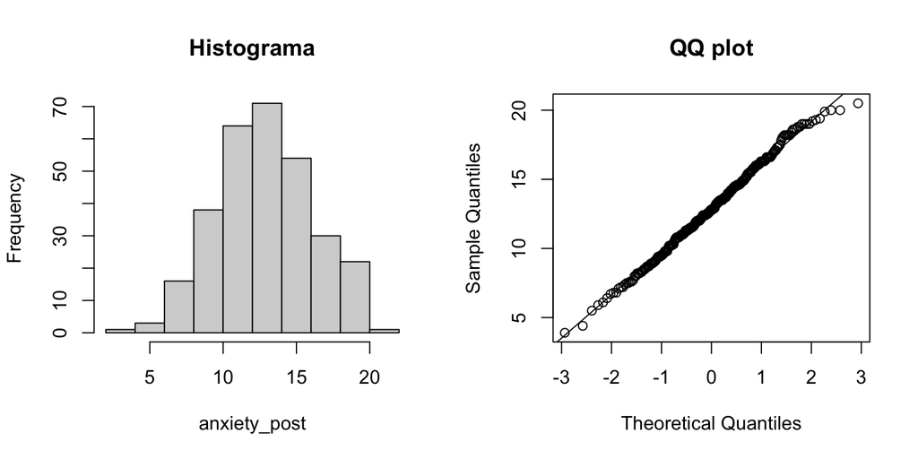

## Supuestos: normalidad

La correlación de **Pearson** asume que ambas variables siguen una distribución normal. Lo comprobamos con un **test formal** (Shapiro-Wilk), cuya $H_0$ es: los datos siguen una distribución normal.

```r
# Shapiro-Wilk: ansiedad post
shapiro.test(x = data_trial$anxiety_post)
```

```
    Shapiro-Wilk normality test

data:  data_trial$anxiety_post
W = 0.9954, p-value = 0.5179
```

```r
# Shapiro-Wilk: bienestar post
shapiro.test(x = data_trial$wellbeing_post)
```

```
    Shapiro-Wilk normality test

data:  data_trial$wellbeing_post
W = 0.99438, p-value = 0.3364
```

- p > 0.05 → no rechazamos $H_0$ → compatible con normalidad
- p < 0.05 → rechazamos $H_0$ → desvío significativo → usar **Spearman**

## `cor.test()` — con la fórmula

```r
# cor.test da r, t, p-valor e intervalo de confianza
correlacion <- cor.test(
  formula = ~ anxiety_post + wellbeing_post,
  data    = data_trial,
  method  = "pearson"
)
correlacion
```

```
    Pearson's product-moment correlation

data:  anxiety_post and wellbeing_post
t = -8.3493, df = 298, p-value = 0.000000000000002614
alternative hypothesis: true correlation is not equal to 0
95 percent confidence interval:
 -0.5228684 -0.3388758
sample estimates:
       cor
-0.4354081
```

En la correlación **no hay VD**: las dos variables están al mismo nivel, así que las dos van a la derecha de `~`.

- **r** = coeficiente de correlación
- **t** = estadístico de contraste
- **p** = significación estadística
- **CI** = rango plausible de valores para r

## El poder de `$`: extraer valores del resultado

El resultado de `cor.test()` es una **lista**: cada pieza tiene un nombre y se extrae con `$`, igual que una columna de un data frame (`data_trial$age`).

```r
# que piezas tiene el resultado
names(correlacion)
```

```
[1] "statistic"   "parameter"   "p.value"     "estimate"    "null.value"  "alternative" "method"      "data.name"
[9] "conf.int"
```

```r
# extraer solo lo que nos interesa
correlacion$estimate   # r
```

```
       cor
-0.4354081
```

```r
correlacion$p.value    # p
```

```
[1] 0.000000000000002614478
```

[figure not shown]

## Si no hay normalidad: Spearman

Misma fórmula; solo cambia el argumento `method`:

```r
# Spearman: basada en rangos, no asume normalidad
correlacion_spearman <- cor.test(
  formula = ~ anxiety_post + wellbeing_post,
  data    = data_trial,
  method  = "spearman"
)
correlacion_spearman
```

```
    Spearman's rank correlation rho

data:  anxiety_post and wellbeing_post
S = 6492117, p-value = 0.0000000000000007879
alternative hypothesis: true rho is not equal to 0
sample estimates:
       rho
-0.4427088
```

## `report::report()` — reportar la correlación

```r
# report() es parte de easystats
library(easystats)

# generar un resumen APA automaticamente
report(x = correlacion)
```

```
Effect sizes were labelled following Funder's (2019) recommendations.

The Pearson's product-moment correlation between anxiety_post and wellbeing_post is negative, statistically
significant, and very large (r = -0.44, 95% CI [-0.52, -0.34], t(298) = -8.35, p < .001)
```

**Tip**

`report::report()` (paquete `easystats`) genera un texto listo para copiar en un artículo: incluye r, CI, p y tamaño del efecto automáticamente.

## Correlaciones entre todas las variables

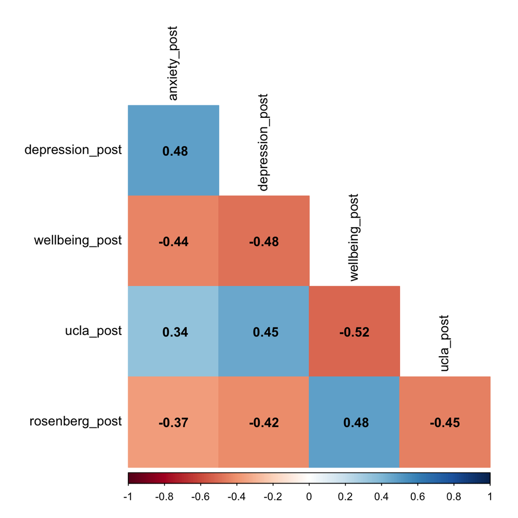

```r
# las cinco medidas post del ensayo
medidas_post <- data_trial |>
  select(ends_with("_post"))

# matriz de correlaciones y sus p-valores
matriz_cor <- cor(
  x      = medidas_post,  # columnas a correlacionar
  method = "pearson"      # o "spearman"
)
matriz_p <- corrplot::cor.mtest(
  mat = medidas_post      # mismas columnas
)$p                       # nos quedamos con los p

# mapa de calor; X = no significativa
corrplot::corrplot(
  corr        = matriz_cor,  # matriz a dibujar
  method      = "color",     # celdas de color
  type        = "lower",     # triangulo inferior
  diag        = FALSE,       # sin diagonal (r = 1)
  addCoef.col = "black",     # escribe r en negro
  p.mat       = matriz_p,    # p-valores
  sig.level   = 0.05,        # umbral: p < .05
  insig       = "pch",       # X si no significativa
  tl.col      = "black"      # nombres en negro
)
```

## Para un artículo: `sjPlot::tab_corr()`

`corrplot()` sirve para **ver** las correlaciones; para la **tabla de un artículo**, `sjPlot::tab_corr()` da los coeficientes con estrellas de significación:

```r
# tabla de correlaciones lista para un manuscrito
sjPlot::tab_corr(
  data        = medidas_post,   # columnas a correlacionar
  triangle    = "lower",        # solo el triángulo inferior
  corr.method = "pearson"       # o "spearman"
)
```

|  | anxiety_post | depression_post | wellbeing_post | ucla_post | rosenberg_post |
| --- | --- | --- | --- | --- | --- |
| anxiety_post |  |  |  |  |  |
| depression_post | 0.483*** |  |  |  |  |
| wellbeing_post | -0.435*** | -0.481*** |  |  |  |
| ucla_post | 0.344*** | 0.450*** | -0.518*** |  |  |
| rosenberg_post | -0.369*** | -0.420*** | 0.485*** | -0.450*** |  |
| Computed correlation used pearson-method with listwise-deletion. |  |  |  |  |  |

## Ejercicio 3 — correlación entre edad y ansiedad

Tiempo: 8 minutos

1. Visualiza la distribución de `age` con un histograma (`hist()`) y un QQ plot (`qqnorm()` + `qqline()`)
2. Comprueba la normalidad de `age` con `shapiro.test()`
3. ¿Es normal? ¿Qué tipo de correlación debemos usar?
4. Calcula la correlación entre `age` y `anxiety_post` con `cor.test()` y la fórmula `~ age + anxiety_post`, usando el método adecuado
5. Genera el resumen APA con `report()`
6. Visualiza la relación con `plot()` y la fórmula `anxiety_post ~ age`

# Comparar dos grupos: `t.test()`

## Un poco de historia: “Student” y la cerveza Guinness

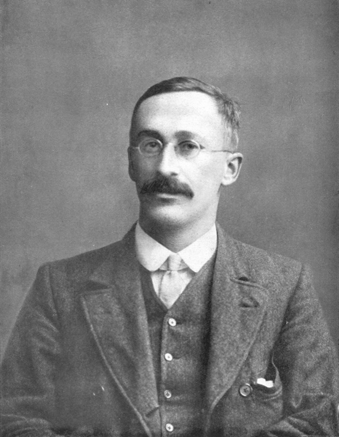

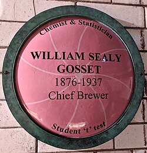

- **William Sealy Gosset** (1876-1937), químico; entró en **Guinness** (Dublín) en 1899 y llegó a cervecero jefe (1935, en la nueva fábrica de Londres)
- Trabajaba con **pocas observaciones**: recuentos de levadura, ensayos con variedades de cebada
- Los métodos de Karl Pearson se usaban con **cientos de observaciones**, donde la desviación típica de la muestra es prácticamente la real; con pocas observaciones esa estimación es incierta y esos métodos **subestiman el error**
- Gosset obtuvo la distribución que incorpora esa incertidumbre (*The probable error of a mean*, *Biometrika*, 1908); con la corrección de Fisher se convirtió en la **distribución *t***
- Después de que otro investigador de Guinness publicara información útil para la competencia, la empresa prohibió publicar con el nombre real: Gosset firmó como **“Student”**, y por eso hablamos del *t* de Student

## Tres *t*-tests

| *t*-test | Pregunta | Ejemplo en el RCT | Código en R |
| --- | --- | --- | --- |
| Una muestra | ¿La media difiere de un valor de referencia? | ¿La ansiedad pre difiere de 10 (punto de corte del GAD-7)? | `t.test(formula =``anxiety_pre``~ 1,` `data = data_trial, mu = 10)` |
| Muestras independientes | ¿Difieren dos grupos? | Farmacológico frente a control en ansiedad pre (basal) | `t.test(formula =``anxiety_pre``~``group``,` `data = datos_2grupos)` |
| Muestras relacionadas (pareado) | ¿Cambia el mismo paciente? | Ansiedad pre frente a post | `t.test(formula = Pair(``anxiety_pre``,``anxiety_post``) ~ 1,` `data = data_trial)` |

Hoy hacemos el de **muestras independientes**.

El pareado usa formato **ancho** (una fila por paciente) y `Pair()`: desde R 4.4, `t.test()` no acepta `paired = TRUE` con una fórmula, porque emparejaba las filas por su orden y no por paciente.

## Pregunta: ¿difieren los grupos farmacológico y control antes del tratamiento?

El *t*-test compara **dos** grupos: nos quedamos con un subconjunto de nuestros datos.

```r
# solo farmacologico y control
datos_2grupos <- data_trial |>
  filter(group %in% c("pharmacological", "control"))

# comprobar: dos grupos de 100 pacientes
pacientes_2grupos <- datos_2grupos |>
  count(group)
pacientes_2grupos
```

```
# A tibble: 2 x 2
  group               n
  <chr>           <int>
1 control           100
2 pharmacological   100
```

**¿Qué esperamos?**

Que **no** haya diferencias en la ansiedad basal (pre): la asignación aleatoria debería dejar los grupos equivalentes antes del tratamiento.

## Paso 1: descriptivos por grupo

```r
# media, desviacion tipica y n por grupo
descriptivos_2grupos <- datos_2grupos |>
  summarise(
    n     = n(),
    media = round(mean(anxiety_pre), 2),
    sd    = round(sd(anxiety_pre), 2),
    .by   = group
  )
descriptivos_2grupos
```

```
# A tibble: 2 x 4
  group               n media    sd
  <chr>           <int> <dbl> <dbl>
1 pharmacological   100  15.6  2.19
2 control           100  15.7  2.14
```

## Paso 2: visualizar

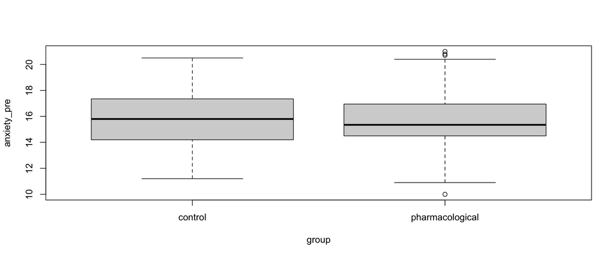

```r
# ansiedad pre en funcion del grupo
boxplot(formula = anxiety_pre ~ group,
        data = datos_2grupos)
```

## Paso 3: supuestos (1/3): normalidad con gráficos

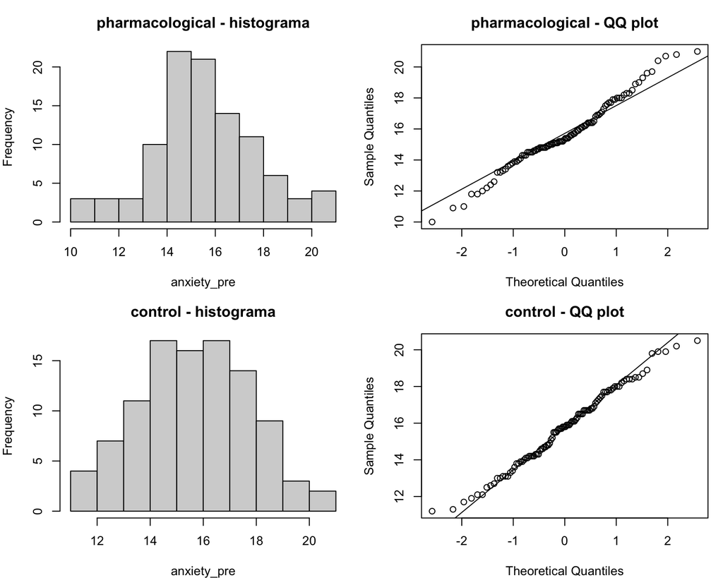

```r
# un subconjunto por grupo
farmaco_g <- datos_2grupos |>
  filter(group == "pharmacological")
control_g <- datos_2grupos |>
  filter(group == "control")

# histograma y QQ plot de cada grupo
hist(x = farmaco_g$anxiety_pre)
qqnorm(y = farmaco_g$anxiety_pre)
qqline(y = farmaco_g$anxiety_pre)
hist(x = control_g$anxiety_pre)
qqnorm(y = control_g$anxiety_pre)
qqline(y = control_g$anxiety_pre)
```

En **cada grupo** buscamos forma de campana y puntos sobre la línea, pero a ojo no siempre está claro: lo comprobamos con una **prueba formal** (Shapiro-Wilk)

## Paso 3: supuestos (2/3): homogeneidad de varianzas

**Homogeneidad de varianzas**: la dispersión de la VD (su varianza) es parecida en todos los grupos. El *t*-test clásico de Student la asume; el de **Welch**, que R usa por defecto, no.

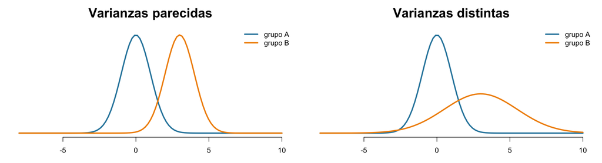

- **A ojo**: en el boxplot del paso 2, cajas de altura parecida
- **Prueba formal**: el test de Levene, $H_0$: las varianzas son iguales

## Paso 3: supuestos (3/3): tests

```r
# normalidad dentro de cada grupo
# p_sw = p-valor de Shapiro-Wilk
# ($p.value extrae solo el p-valor del test)
normalidad_2grupos <- datos_2grupos |>
  summarise(
    p_sw = shapiro.test(x = anxiety_pre)$p.value,
    .by = group
  )
normalidad_2grupos
```

```
# A tibble: 2 x 2
  group            p_sw
  <chr>           <dbl>
1 pharmacological 0.216
2 control         0.519
```

```r
# homogeneidad de varianzas (Levene)
# H0: las varianzas son iguales
# en leveneTest() la formula va en el argumento y
resultado_levene <- leveneTest(
  y    = anxiety_pre ~ group,
  data = datos_2grupos
)
resultado_levene
```

```
Levene's Test for Homogeneity of Variance (center = median)
       Df F value Pr(>F)
group   1  0.1767 0.6746
      198
```

- Shapiro-Wilk p > 0.05 en los dos grupos → compatible con normalidad
- Levene p > 0.05 → no hay evidencia de que las varianzas difieran (no demuestra que sean iguales)

## Paso 4: `t.test()`

```r
# t-test de muestras independientes
resultado_t <- t.test(formula = anxiety_pre ~ group,
                      data = datos_2grupos)
resultado_t
```

```
    Welch Two Sample t-test

data:  anxiety_pre by group
t = 0.26766, df = 197.87, p-value = 0.7892
alternative hypothesis: true difference in means between group control and group pharmacological is not equal to 0
95 percent confidence interval:
 -0.5221372  0.6861372
sample estimates:
        mean in group control mean in group pharmacological
                       15.737                        15.655
```

- Por defecto, R usa el *t*-test de **Welch** (`var.equal = FALSE`): no necesita varianzas iguales
- **t**, **df** y **p**: el contraste
- **95 percent confidence interval**: IC de la diferencia de medias (control − farmacológico, por orden alfabético)
- **mean in group**: la media de cada grupo

## Paso 5: tamaño del efecto

```r
# d de Cohen: diferencia de medias en unidades de desviacion tipica
# en cohens_d() el argumento de la formula se llama x
tamano_efecto <- cohens_d(x = anxiety_pre ~ group, data = datos_2grupos)
tamano_efecto
```

```
Cohen's d |        95% CI
-------------------------
0.04      | [-0.24, 0.32]

- Estimated using pooled SD.
```

- Referencias de Cohen (1988): |d| ≈ 0.2 pequeño, 0.5 mediano, 0.8 grande
- El signo indica la dirección: primer grupo (control) menos segundo (farmacológico), por orden alfabético

## Paso 6: `report::report()` — reportar el *t*-test

```r
# resumen APA; con data = el tamano del efecto se calcula a partir de los datos
report(x = resultado_t, data = datos_2grupos)
```

```
Effect sizes were labelled following Cohen's (1988) recommendations.

The Welch Two Sample t-test testing the difference of anxiety_pre by group (mean in group control = 15.74, mean in
group pharmacological = 15.65) suggests that the effect is positive, statistically not significant, and very small
(difference = 0.08, 95% CI [-0.52, 0.69], t(197.87) = 0.27, p = 0.789; Cohen's d = 0.04, 95% CI [-0.24, 0.32])
```

## Ejercicio 4 — farmacológico frente a control

Tiempo: 12 minutos

Mismos grupos, ahora **después** del tratamiento: ¿difiere la ansiedad post entre el grupo **farmacológico** y el **control**?

1. Crea `datos_farmaco` con solo los grupos `"pharmacological"` y `"control"`
2. Calcula n, media y desviación típica de `anxiety_post` por grupo
3. Visualiza con `boxplot()` y la fórmula `anxiety_post ~ group`
4. Comprueba los supuestos: histograma y QQ plot de cada grupo, `shapiro.test()` (por grupo) y `leveneTest()`
5. Haz el *t*-test con `t.test()`
6. Calcula el tamaño del efecto con `cohens_d()` y genera el resumen con `report()`

## Resumen del bloque 2

La fórmula en R: `VD ~ VI`

`VD ~ VI``+``*``~ 1`

Correlación: `cor.test()`

`plot()``shapiro.test()``cor.test()``method = "spearman"``$``report()``interpret_r()``cor()``corrplot()``tab_corr()`

Comparar dos grupos: `t.test()`

`filter()``%in%``boxplot()``leveneTest()``t.test()``cohens_d()`

Con borde naranja: funciones **nuevas** de este bloque.